# 回归分析

# 1 回归分析

## 1.1 加载包

```r
library(readxl)
library(dplyr)
library(writexl)
library(StepReg)
library(lmtest)
```

```r
library(ggplot2)
library(leaps)
library(car)
library(lmtest)
library(DT)
```

## 1.2 读取数据

```r
salary <- read_excel("data.xlsx")
summary(salary)
```

```
##      职位               位置                年薪             福利
##  Length:9865        Length:9865        Min.   :  0.5475   Mode :logical
##  Class :character   Class :character   1st Qu.:  6.0000   FALSE:5885
##  Mode  :character   Mode  :character   Median :  7.8000   TRUE :3980
##                                        Mean   : 11.2779
##                                        3rd Qu.: 12.0000
##                                        Max.   :306.0000
##  已有工作经验           学历             公司行业           融资阶段
##  Length:9865        Length:9865        Length:9865        Length:9865
##  Class :character   Class :character   Class :character   Class :character
##  Mode  :character   Mode  :character   Mode  :character   Mode  :character
##
##
##
##    公司规模           职业类别           log_salary
##  Length:9865        Length:9865        Min.   :-0.6024
##  Class :character   Class :character   1st Qu.: 1.7918
##  Mode  :character   Mode  :character   Median : 2.0541
##                                        Mean   : 2.1651
##                                        3rd Qu.: 2.4849
##                                        Max.   : 5.7236
```

## 1.3 处理数据

```r
# 公司规模哑变量赋值
df1 <- data.frame(salary$公司规模)
df1 <- factor(df1, levels = c("100以下", "100-499", "500以上"))
dummy_scale <- model.matrix(~ salary$公司规模 - 1, data = salary)
salary <- cbind(salary, dummy_scale)
salary <- subset(salary, select = -公司规模)
```

```r
# 已有工作经验哑变量赋
df2 <- data.frame(salary$已有工作经验)
df2 <- factor(df2, levels = c("1年以内", "1-3年", "3-5年", "5年以上", "经验不限"))
dummy_experience <- model.matrix(~ salary$已有工作经验 - 1, data = salary)
salary <- cbind(salary, dummy_experience)
salary <- subset(salary, select = -已有工作经验)
```

```r
# 学历哑变量赋值
df3 <- data.frame(salary$学历)
df3 <- factor(df3, levels = c("本科", "高中及以下", "大专", "研究生", "学历不限"))
dummy_degree <- model.matrix(~ salary$学历 - 1, data = salary)
salary <- cbind(salary, dummy_degree)
salary <- subset(salary, select = -学历)
```

```r
# 融资阶段哑变量赋值
df4 <- data.frame(salary$学历)
df4 <- factor(df4, levels = c("不需要融资", "准备融资", "正在融资", "已上市", "未知"))
dummy_phase <- model.matrix(~ salary$融资阶段 - 1, data = salary)
salary <- cbind(salary, dummy_phase)
salary <- subset(salary, select = -融资阶段)
```

```r
# 福利哑变量赋值
salary <- salary %>%
  mutate(福利 = case_when(
    福利 == TRUE ~ 1,
    福利 == FALSE ~ 0,
    TRUE ~ 福利
  ))
salary$福利 <- as.integer(salary$福利)
```

```r
# 位置哑变量赋值
df5 <- data.frame(salary$位置)
df5 <- factor(df5, levels = c("东部地区", "中部地区", "南部地区", "西部地区", "未知"))
dummy_location <- model.matrix(~ salary$位置 - 1, data = salary)
salary <- cbind(salary, dummy_location)
salary <- subset(salary, select = -位置)
```

```r
# 公司行业哑变量赋值
df6 <- data.frame(salary$公司行业)
df6 <- factor(df6, levels = c("金融互联网", "公共服务", "机械制造", "媒体教培", "商业服务"))
dummy_industry <- model.matrix(~ salary$公司行业 - 1, data = salary)
salary <- cbind(salary, dummy_industry)
salary <- subset(salary, select = -公司行业)
```

```r
# 职业类别哑变量赋值
df7 <- data.frame(salary$公司行业)
df7 <- factor(df7, levels = c("商务与工程类", "法务与咨询类", "媒体与培训类", "销售与服务类", "其他职业类"))
dummy_category <- model.matrix(~ salary$职业类别 - 1, data = salary)

# 处理表格
salary <- subset(salary, select = -职业类别)
salary <- subset(salary, select = -职位)
salary <- subset(salary, select = -年薪)
salary <- subset(salary, select = -`salary$公司规模100-499`)
salary <- subset(salary, select = -`salary$已有工作经验1-3年`)
salary <- subset(salary, select = -`salary$融资阶段未知`)
salary <- subset(salary, select = -`salary$位置中部地区`)
salary <- subset(salary, select = -`salary$公司行业媒体教培`)
salary <- subset(salary, select = -`salary$学历本科`)
colnames(salary) <- gsub("\\$", "_", colnames(salary))
```

## 1.4 回归

```r
myfit0 <- lm(log_salary ~ ., data = salary)
summary(myfit0)
```

```
##
## Call:
## lm(formula = log_salary ~ ., data = salary)
##
## Residuals:
##     Min      1Q  Median      3Q     Max
## -2.7403 -0.3101 -0.0337  0.2738  3.7675
##
## Coefficients:
##                             Estimate Std. Error t value Pr(>|t|)
## (Intercept)                  2.13599    0.02434  87.772  < 2e-16 ***
## 福利                         0.08534    0.01204   7.090 1.43e-12 ***
## salary_公司规模100以下      -0.06062    0.01307  -4.638 3.57e-06 ***
## salary_公司规模500以上       0.08597    0.01899   4.526 6.07e-06 ***
## salary_已有工作经验1年以内  -0.19340    0.01905 -10.150  < 2e-16 ***
## `salary_已有工作经验3-5年`   0.24808    0.01550  16.002  < 2e-16 ***
## salary_已有工作经验5年以上   0.62635    0.02092  29.944  < 2e-16 ***
## salary_已有工作经验经验不限 -0.05690    0.01272  -4.473 7.81e-06 ***
## salary_学历大专             -0.29960    0.01394 -21.494  < 2e-16 ***
## salary_学历高中及以下       -0.34072    0.01764 -19.312  < 2e-16 ***
## salary_学历学历不限         -0.22036    0.01538 -14.326  < 2e-16 ***
## salary_学历研究生            0.73936    0.03527  20.960  < 2e-16 ***
## salary_融资阶段不需要融资    0.07666    0.01394   5.500 3.89e-08 ***
## salary_融资阶段已上市        0.09692    0.02764   3.507 0.000455 ***
## salary_融资阶段正在融资      0.27516    0.02769   9.937  < 2e-16 ***
## salary_融资阶段准备融资      0.06055    0.01324   4.572 4.90e-06 ***
## salary_位置东北地区         -0.05659    0.02356  -2.402 0.016346 *
## salary_位置东部地区          0.22963    0.01267  18.131  < 2e-16 ***
## salary_位置南部地区          0.09550    0.01421   6.723 1.89e-11 ***
## salary_位置西部地区          0.05430    0.01658   3.275 0.001061 **
## salary_公司行业公共服务     -0.01159    0.01767  -0.656 0.512114
## salary_公司行业机械制造     -0.03649    0.02151  -1.696 0.089935 .
## salary_公司行业金融互联网    0.11441    0.01685   6.788 1.20e-11 ***
## salary_公司行业商业服务     -0.03427    0.01651  -2.076 0.037917 *
## ---
## Signif. codes:  0 '***' 0.001 '**' 0.01 '*' 0.05 '.' 0.1 ' ' 1
##
## Residual standard error: 0.481 on 9841 degrees of freedom
## Multiple R-squared:  0.4019, Adjusted R-squared:  0.4005
## F-statistic: 287.5 on 23 and 9841 DF,  p-value: < 2.2e-16
```

### 1.4.1 残差图

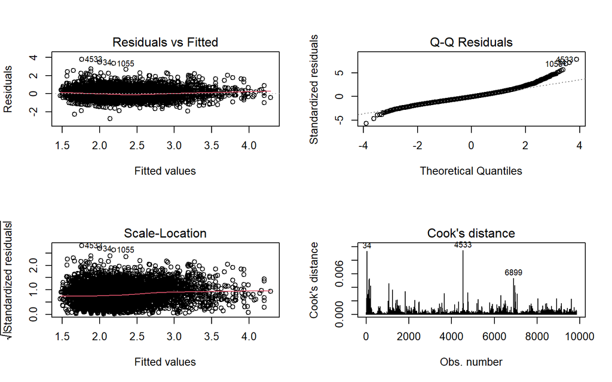

```r
par(mfrow = c(2, 2))
plot(myfit0, c(1:4))
```

```r
par(mfrow = c(1, 1))
```

### 1.4.2 异方差检验

#### 1.4.2.1 Spearman Test

对每一个自变量$x_i$与残差的绝对值两两检验。

```r
p <- rep(1, ncol(salary)) # 初始化

for (i in seq_along(p)) {
  if (colnames(salary)[i] != "log_salary") {
    p[i] <- cor.test(as.numeric(salary[, i]), abs(myfit0$residuals))$p.value
  }
}

names(p) <- colnames(salary)
p <= 0.1
##                        福利                  log_salary
##                        TRUE                       FALSE
##      salary_公司规模100以下      salary_公司规模500以上
##                        TRUE                        TRUE
##  salary_已有工作经验1年以内    salary_已有工作经验3-5年
##                       FALSE                       FALSE
##  salary_已有工作经验5年以上 salary_已有工作经验经验不限
##                        TRUE                       FALSE
##             salary_学历大专       salary_学历高中及以下
##                        TRUE                        TRUE
##         salary_学历学历不限           salary_学历研究生
##                       FALSE                        TRUE
##   salary_融资阶段不需要融资       salary_融资阶段已上市
##                       FALSE                       FALSE
##     salary_融资阶段正在融资     salary_融资阶段准备融资
##                        TRUE                       FALSE
##         salary_位置东北地区         salary_位置东部地区
##                       FALSE                        TRUE
##         salary_位置南部地区         salary_位置西部地区
##                       FALSE                        TRUE
##     salary_公司行业公共服务     salary_公司行业机械制造
##                        TRUE                        TRUE
##   salary_公司行业金融互联网     salary_公司行业商业服务
##                        TRUE                        TRUE
```

可见，存在$p<0.1$，即存在异方差问题。

> 注：书本只有一元回归的检验方法，此处增加了多元回归的异方差检验方法如下。

#### 1.4.2.2 Breusch-Pagan Test

使用**Breusch-Pagan Test**进行检验[^1]。

$$H_0:\{模型myfit0不存在异方差现象\}$$

```r
bptest(myfit0)
##
##  studentized Breusch-Pagan test
##
## data:  myfit0
## BP = 309.67, df = 23, p-value < 2.2e-16
```

由于$p<0.05$，于是在95%的置信水平下拒绝原假设，认为存在异方差问题。

### 1.4.3 自相关检验

#### 1.4.3.1 绘图

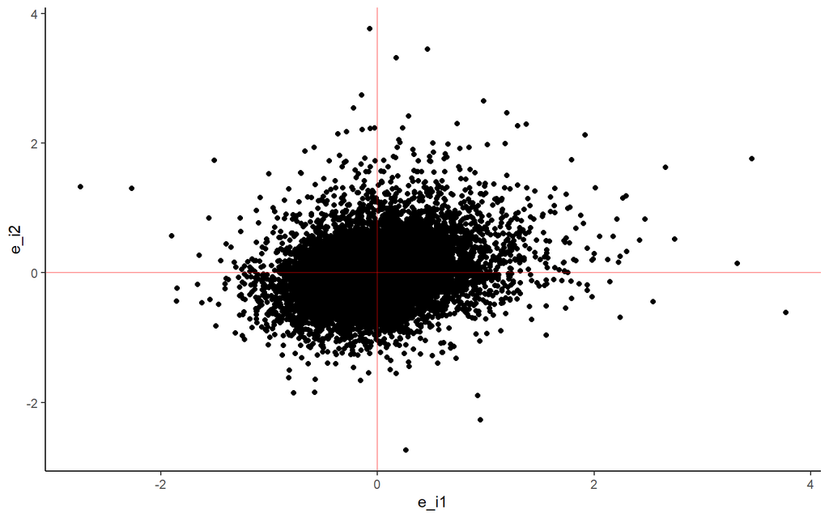

```r
n <- nrow(salary)
e_i1 <- myfit0$residuals[1:(n - 1)]
e_i2 <- myfit0$residuals[2:n]

ggplot() +
  geom_point(mapping = aes(x = e_i1, y = e_i2)) +
  geom_vline(xintercept = 0, col = "red", alpha = 0.4) +
  geom_hline(yintercept = 0, col = "red", alpha = 0.4) +
  theme_classic()
```

点无规则地落在坐标原点四周，无明显规律性。

#### 1.4.3.2 DW检验

```r
dwtest(myfit0, alternative = "two.sided")
##
##  Durbin-Watson test
##
## data:  myfit0
## DW = 1.469, p-value < 2.2e-16
## alternative hypothesis: true autocorrelation is not 0
```

可见，在95%置信水平下**拒绝**原假设。即认为存在一阶自相关性。

### 1.4.4 多重共线性检验

```r
cor(salary)
```

```
##                                    福利   log_salary salary_公司规模100以下
## 福利                         1.00000000  0.271631823           -0.294601288
## log_salary                   0.27163182  1.000000000           -0.208210239
## salary_公司规模100以下      -0.29460129 -0.208210239            1.000000000
## salary_公司规模500以上       0.25300894  0.182908378           -0.560086019
## salary_已有工作经验1年以内  -0.01633610 -0.121584230            0.011725890
## salary_已有工作经验3-5年     0.09314194  0.209850269           -0.052578087
## salary_已有工作经验5年以上   0.08803642  0.351711189           -0.094417396
## salary_已有工作经验经验不限 -0.11477263 -0.208607923            0.051425679
## salary_学历大专              0.04540677 -0.097359912           -0.018879167
## salary_学历高中及以下       -0.08487198 -0.167833142            0.038849260
## salary_学历学历不限         -0.20139793 -0.182307790            0.114333996
## salary_学历研究生            0.09296572  0.304724588           -0.084694110
## salary_融资阶段不需要融资    0.15486318  0.032464856           -0.067295129
## salary_融资阶段已上市        0.21172196  0.128359211           -0.290410064
## salary_融资阶段正在融资      0.16845252  0.211334794           -0.163867036
## salary_融资阶段准备融资      0.23610279  0.052475862           -0.030847042
## salary_位置东北地区         -0.03613087 -0.074920423            0.031364938
## salary_位置东部地区          0.14046713  0.248794759           -0.048067329
## salary_位置南部地区         -0.02014361 -0.020898579           -0.009431813
## salary_位置西部地区         -0.03176222 -0.060196187            0.023421483
## salary_公司行业公共服务     -0.01063075 -0.043901336           -0.045779657
## salary_公司行业机械制造      0.01429981 -0.003193947           -0.016250768
## salary_公司行业金融互联网    0.17982533  0.217425925           -0.091039798
## salary_公司行业商业服务     -0.13829568 -0.123675228            0.035784062
##                             salary_公司规模500以上 salary_已有工作经验1年以内
## 福利                                   0.253008938               -0.016336097
## log_salary                             0.182908378               -0.121584230
## salary_公司规模100以下                -0.560086019                0.011725890
## salary_公司规模500以上                 1.000000000                0.004802939
## salary_已有工作经验1年以内             0.004802939                1.000000000
## salary_已有工作经验3-5年               0.034515145               -0.127050092
## salary_已有工作经验5年以上             0.048405335               -0.082698949
## salary_已有工作经验经验不限           -0.010113433               -0.241504153
## salary_学历大专                       -0.023568598                0.025276697
## salary_学历高中及以下                 -0.022613567                0.048189433
## salary_学历学历不限                   -0.096169411               -0.042046369
## salary_学历研究生                      0.046468891                0.014842746
## salary_融资阶段不需要融资              0.029720500                0.012067857
## salary_融资阶段已上市                  0.444503964                0.011177704
```

[output cut: 245 more lines]

```
## salary_学历高中及以下                   0.029973080
## salary_学历学历不限                     0.085108561
## salary_学历研究生                      -0.061372654
## salary_融资阶段不需要融资              -0.001226923
## salary_融资阶段已上市                  -0.060623774
## salary_融资阶段正在融资                -0.081728058
## salary_融资阶段准备融资                -0.044815236
## salary_位置东北地区                    -0.003755652
## salary_位置东部地区                    -0.089119395
## salary_位置南部地区                     0.025348382
## salary_位置西部地区                     0.030306836
## salary_公司行业公共服务                -0.330836368
## salary_公司行业机械制造                -0.204294937
## salary_公司行业金融互联网              -0.408351089
## salary_公司行业商业服务                 1.000000000
```

```r
alias(myfit0, complete = TRUE) # 完全多重共线性
## Model :
## log_salary ~ 福利 + salary_公司规模100以下 + salary_公司规模500以上 +
##     salary_已有工作经验1年以内 + `salary_已有工作经验3-5年` +
##     salary_已有工作经验5年以上 + salary_已有工作经验经验不限 +
##     salary_学历大专 + salary_学历高中及以下 + salary_学历学历不限 +
##     salary_学历研究生 + salary_融资阶段不需要融资 +
##     salary_融资阶段已上市 + salary_融资阶段正在融资 +
##     salary_融资阶段准备融资 + salary_位置东北地区 +
##     salary_位置东部地区 + salary_位置南部地区 + salary_位置西部地区 +
##     salary_公司行业公共服务 + salary_公司行业机械制造 +
##     salary_公司行业金融互联网 + salary_公司行业商业服务

sort(vif(myfit0), decreasing = TRUE) # 多重共线性
##   salary_公司行业金融互联网     salary_公司行业商业服务
##                    2.452454                    2.430428
##         salary_学历学历不限     salary_公司行业公共服务
##                    2.195140                    2.170352
##      salary_公司规模500以上             salary_学历大专
##                    1.698292                    1.680579
## salary_已有工作经验经验不限     salary_公司行业机械制造
##                    1.643634                    1.608231
##       salary_学历高中及以下      salary_公司规模100以下
##                    1.574460                    1.573962
##         salary_位置东部地区     salary_融资阶段准备融资
##                    1.551387                    1.497824
##       salary_融资阶段已上市                        福利
##                    1.492376                    1.486591
##   salary_融资阶段不需要融资         salary_位置南部地区
##                    1.404609                    1.404196
##  `salary_已有工作经验3-5年`         salary_位置西部地区
##                    1.314766                    1.282671
##     salary_融资阶段正在融资  salary_已有工作经验5年以上
##                    1.250469                    1.216750
##  salary_已有工作经验1年以内         salary_位置东北地区
##                    1.179776                    1.136955
##           salary_学历研究生
##                    1.089855

mean(vif(myfit0))
## [1] 1.579816
```

## 1.6 模型选择

采用**逐步回归**的方法，在不同的准则下选择变量。

### 1.6.1 $R_{adjust}^2$准则

```r
salary.r2adj <- leaps(x = salary[, -2], y = salary[, 2], method = "adjr2")
result <- cbind(salary.r2adj$which, adjRsq = salary.r2adj$adjr2)
optimal_model_index <- which.max(salary.r2adj$adjr2)
optimal_model <- result[optimal_model_index, ]
print(optimal_model)
```

```
##        1        2        3        4        5        6        7        8
## 1.000000 1.000000 1.000000 1.000000 1.000000 1.000000 1.000000 1.000000
##        9        A        B        C        D        E        F        G
## 1.000000 1.000000 1.000000 1.000000 1.000000 1.000000 1.000000 1.000000
##        H        I        J        K        L        M        N   adjRsq
## 1.000000 1.000000 1.000000 0.000000 1.000000 1.000000 1.000000 0.400492
```

### 1.6.2 AIC、BIC、$C_p$准则

首先编写所需要的函数：

```r
select_model <- function(data, metric, y_name, strategy = "bidirection") {
  # data0: 数据框
  # metric: 模型选择准则 ("AIC", "BIC", "CP")
  # y_name: 因变量名称
  # strategy: 回归策略 ("forward", "backward", "bidirection", "subset")

  # 获取所有自变量名称
  total_variate <- setdiff(colnames(data), y_name)
  data_ <- data.frame(data)

  # 使用stepwise函数进行变量选择
  fit <- stepwise(
    formula = as.formula(paste(y_name, "~ .")),
    data = data_,
    type = "linear",
    strategy = strategy,
    metric = metric
  )

  # 从lm模型中提取变量
  corrected_variable_names <- gsub(
    "\\.", "-", fit[["variables"]][["Variable_name"]]
  )
  model_terms <- corrected_variable_names[-1]

  # 创建结果数据框
  result <- data.frame(
    variable = total_variate,
    selected = total_variate %in% model_terms
  )

  return(list(
    model = fit, # stepwise的完整结果
    selected_vars = model_terms, # 选中的变量
    selection_result = result # 变量选择结果表
  ))
}
```

AIC、BIC、$C_p$准则下的变量选择：

```r
aic_result <- select_model(salary, metric = "AIC", y_name = "log_salary")
bic_result <- select_model(salary, metric = "BIC", y_name = "log_salary")
cp_result <- select_model(salary, metric = "CP", y_name = "log_salary")
```

比较三种准则下的变量选择结果：

```r
# 创建比较表
comparison <- data.frame(
  variable = aic_result$selection_result$variable,
  AIC = aic_result$selection_result$selected,
  BIC = bic_result$selection_result$selected,
  CP = cp_result$selection_result$selected
)

# 显示比较结果
datatable(comparison,
  caption = "三种准则变量选择结果比较",
  options = list(scrollX = TRUE)
)
```

|  | variable | AIC | BIC | CP |
| --- | --- | --- | --- | --- |
| 1 | 福利 | True | True | True |
| 2 | salary_公司规模100以下 | True | True | True |
| 3 | salary_公司规模500以上 | True | True | True |
| 4 | salary_已有工作经验1年以内 | True | True | True |
| 5 | salary_已有工作经验3-5年 | True | True | True |
| 6 | salary_已有工作经验5年以上 | True | True | True |
| 7 | salary_已有工作经验经验不限 | True | True | True |
| 8 | salary_学历大专 | True | True | True |
| 9 | salary_学历高中及以下 | True | True | True |
| 10 | salary_学历学历不限 | True | True | True |

[output cut: 13 more lines]

### 1.6.3 对比

在**AIC准则**、**BIC准则**和**$C_p$准则**之间，三者所选的变量相同，考虑到多重共线性并结合三个准则，确定模型为”myfit0”。

### 1.6.4 多重共线性分析

```r
sort(vif(myfit0), decreasing = TRUE) # 多重共线性
##   salary_公司行业金融互联网     salary_公司行业商业服务
##                    2.452454                    2.430428
##         salary_学历学历不限     salary_公司行业公共服务
##                    2.195140                    2.170352
##      salary_公司规模500以上             salary_学历大专
##                    1.698292                    1.680579
## salary_已有工作经验经验不限     salary_公司行业机械制造
##                    1.643634                    1.608231
##       salary_学历高中及以下      salary_公司规模100以下
##                    1.574460                    1.573962
##         salary_位置东部地区     salary_融资阶段准备融资
##                    1.551387                    1.497824
##       salary_融资阶段已上市                        福利
##                    1.492376                    1.486591
##   salary_融资阶段不需要融资         salary_位置南部地区
##                    1.404609                    1.404196
##  `salary_已有工作经验3-5年`         salary_位置西部地区
##                    1.314766                    1.282671
##     salary_融资阶段正在融资  salary_已有工作经验5年以上
##                    1.250469                    1.216750
##  salary_已有工作经验1年以内         salary_位置东北地区
##                    1.179776                    1.136955
##           salary_学历研究生
##                    1.089855

mean(vif(myfit0))
## [1] 1.579816
```

可见，$\bar{VIF}$未明显大于1，且$VIF_j<10$均成立，故可认为消除了多重共线性。

### 1.6.5 异方差检验

#### 1.6.5.1 Breusch-Pagan Test

使用**Breusch-Pagan Test**进行检验[^2]。

$$H_0:\{模型myfit0不存在异方差现象\}$$

```r
bptest(myfit0)
##
##  studentized Breusch-Pagan test
##
## data:  myfit0
## BP = 309.67, df = 23, p-value < 2.2e-16
```

### 1.6.6 自相关检验

#### 1.6.6.1 DW检验

```r
dwtest(myfit0, alternative = "two.sided")
##
##  Durbin-Watson test
##
## data:  myfit0
## DW = 1.469, p-value < 2.2e-16
## alternative hypothesis: true autocorrelation is not 0
```

### 1.6.7 正态性检验

使用**Kolmogorov-Smirnov Test**检验模型残差的正态性。

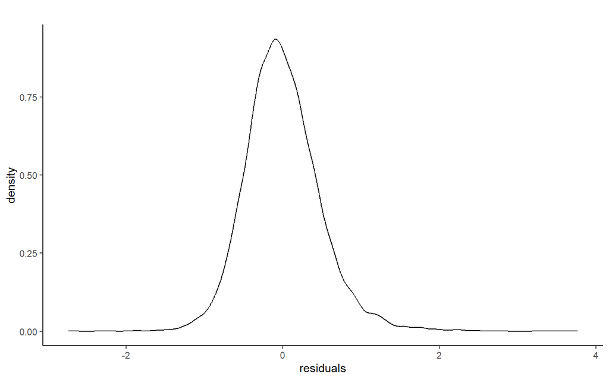

```r
ks.test(myfit0$residuals, y = pnorm, mean(myfit0$residuals), sd(myfit0$residuals))
##
##  Asymptotic one-sample Kolmogorov-Smirnov test
##
## data:  myfit0$residuals
## D = 0.040237, p-value = 2.676e-14
## alternative hypothesis: two-sided

ggplot() +
  geom_density(mapping = aes(x = myfit0$residuals)) +
  labs(title = "残差密度分布图", x = "residuals") +
  theme_classic() +
  theme(plot.title = element_text(hjust = 0.5))
```

## 1.8 参考

[^1]: [How to Perform a Breusch-Pagan Test in R︎](https://www.statology.org/breusch-pagan-test-r/)
[^2]: [How to Perform a Breusch-Pagan Test in R︎](https://www.statology.org/breusch-pagan-test-r/)